# One Sample T-Test

**Table of Contents**

1. The One Sample T-Test
2. Decision Rule
   1. Two-sided Test
   2. One-sided Test
3. Examples (Not Complete)
   1. Calculating Power
   2. Calculating Sample Size
   3. Minimum Change
   4. Standard Deviation
   5. Significance Level
4. Study Design Derivations
   1. Power
   2. Sample Size (Not Complete)
   3. Minimum Change (Not Complete)
   4. Standard Deviation (Not Complete)
   5. Significance Level (Not Complete)
5. References

## 1. The One Sample T-Test

The one sample t-test is commonly used to look for evidence that the mean of a normally distributed random variable may differ from a hypothesized (or previously observed) value. The hypotheses for these test take the forms:

For a two-sided test: $\begin{align} H_0: \mu &= \mu_0\\ H_1: \mu &\neq \mu_0 \end{align}$

For a one-sided test: $\begin{align} H_0: \mu &< \mu_0\\ H_1: \mu &\geq \mu_0 \end{align}$

or $\begin{align} H_0: \mu &> \mu_0\\ H_1: \mu &\leq \mu_0 \end{align}$

To compare a sample $(X_1, \ldots, X_n)$ against the hypothesized value, a T-statistic is calculated in the form:

$T = \frac{\bar{x} - \mu_0}{s / \sqrt{n}}$

Where $\bar{x}$ is the sample mean and $s$ is the sample standard deviation.

## 2. Decision Rule

The decision to reject a null hypothesis is made when an observed T-value lies in a critical region that suggests the probability of that observation is low. We define the critical region as the upper bound we are willing to accept for $\alpha$, the Type I Error.

### Two-Sided Test

In the two-sided test, $\alpha$ is shared equally in both tails. The rejection regions for the most common values of $\alpha$ are depicted in the figure below, with the sum of shaded areas on both sides equaling the corresponding $\alpha$. It follows, then, that the decision rule is:

Reject $H_0$ when $T \leq t_{\alpha/2, n-1}$ or when $T \geq t_{1-\alpha/2, n-1}$.

By taking advantage of the symmetry of the T-distribution, we can simplify the decision rule to:

Reject $H_0$ when $|T| \geq t_{1-\alpha/2, n-1}$

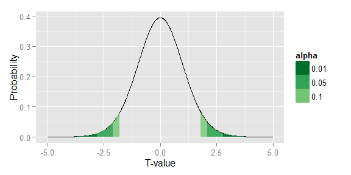

The example displayed uses 25 degrees of freedom

### One Sided Test

In the one-sided test, $\alpha$ is placed in only one tail. The rejection regions for the most common values of $\alpha$ are depicted in the figure below. In each case, $\alpha$ is the area in the tail of the figure. It follows, then, that the decision rule for a lower tailed test is:

Reject $H_0$ when $T \leq t_{\alpha, n-1}$.

For an upper tailed test, the decision rule is:

Reject $H_0$ when $T \geq t_{1-\alpha, n-1}$.

Again, by using the symmetry of the T-distribution, we can simplify the decision rule as:

Reject $H_0$ when $|T| \geq t_{1-\alpha, n-1}$.

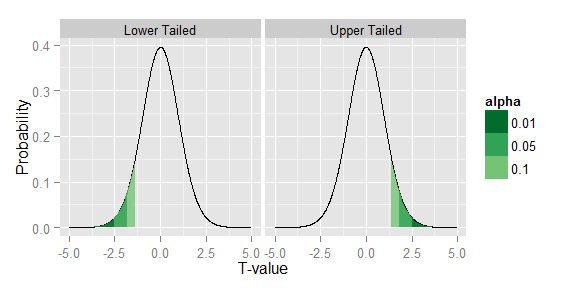

The example displayed uses 25 degrees of freedom

### Decision Rules In Terms of $\bar{x}$

The decision rule can also be written in terms of $\bar{x}$:

Reject $H_0$ when $\bar{x} \leq \mu_0 - t_\alpha \cdot s/\sqrt{n}$ or $\bar{x} \geq \mu_0 + t_\alpha \cdot s/\sqrt{n}$.

This change can be justified by:

$\begin{align} |T| &\geq t_{1-\alpha, n-1}\\ \Big|\frac{\bar{x} - \mu_0}{s/\sqrt{n}}\Big| &\geq t_{1-\alpha, n-1} \end{align}$

$\begin{align} -\Big(\frac{\bar{x} - \mu_0}{s/\sqrt{n}}\Big) &\geq t_{1-\alpha, n-1} & \frac{\bar{x} - \mu_0}{s/\sqrt{n}} &\geq t_{1-\alpha, n-1}\\ \bar{x} - \mu_0 &\leq - t_{1-\alpha, n-1} \cdot s/\sqrt{n} & \bar{x} - \mu_0 &\geq t_{1-\alpha, n-1} \cdot s/\sqrt{n}\\ \bar{x} &\leq \mu_0 - t_{1-\alpha, n-1} \cdot s/\sqrt{n} & \bar{x} &\geq \mu_0 + t_{1-\alpha, n-1} \cdot s/\sqrt{n} \end{align}$

For a two-sided test, both the conditions apply. The left side condition is used for a left-tailed test, and the right side condition for a right-tailed test.

## 3. Examples

## 4. Study Design Derivations

The derivations below make use of the following symbols:

- $\bar{x}$: The sample mean
- $s$: The sample standard deviation
- $n$: The sample size
- $\mu_0$: The value of population mean under the null hypothesis
- $\mu$: The value of the population mean under the alternative hypothesis.
- $\alpha$: The significance level
- $\gamma(\mu)$: The power of the test for the parameter $\mu$.
- $t_{\alpha, n-1}$: A quantile of the central t-distribution for a probability, $\alpha$ and $n-1$ degrees of freedom.
- $T$: A calculated value to be compared against a t-distribution.
- $C$: The critical region (rejection region) of the test.

### 4a. Power

#### Two-Sided Test

$\begin{align} \gamma(\mu) &= P_\mu(\bar{x} \in C)\\ &= P_\mu\big(\bar{x} \leq \mu_0 - t_{\alpha/2, n-1} \cdot s/\sqrt{n}\big) + P_\mu\big(\bar{x} \geq \mu_0 + t_{1-\alpha/2, n-1} \cdot s/\sqrt{n}\big)\\ &= P_\mu\big(\bar{x} - \mu \leq \mu_0 - \mu - t_{\alpha/2, n-1} \cdot s/\sqrt{n}\big) + P_\mu\big(\bar{x} - \mu \geq \mu_0 - \mu + t_{1-\alpha/2, n-1} \cdot s/\sqrt{n}\big)\\ &= P_\mu\Big(\frac{\bar{x} - \mu}{s/\sqrt{n}} \leq \frac{\mu_0 - \mu - t_{\alpha/2, n-1} \cdot s/\sqrt{n}}{s/\sqrt{n}}\Big) + P_\mu\Big(\frac{\bar{x} - \mu}{s/\sqrt{n}} \geq \frac{\mu_0 - \mu + t_{1-\alpha/2, n-1} \cdot s/\sqrt{n}}{s/\sqrt{n}}\Big)\\ &= P_\mu\Big(T \leq \frac{\mu_0 - \mu}{s/\sqrt{n}} - t_{\alpha/2, n-1}\Big) + P_\mu\Big(T \geq \frac{\mu_0 - \mu}{s/\sqrt{n}} + t_{1-\alpha/2, n-1}\Big)\\ &= P_\mu\Big(T \leq -t_{\alpha/2, n-1} + \frac{\mu_0 - \mu}{s/\sqrt{n}}\Big) + P_\mu\Big(T \geq t_{1-\alpha/2, n-1} + \frac{\mu_0 - \mu}{s/\sqrt{n}}\Big)\\ &= P_\mu\Big(T \leq -t_{\alpha/2, n-1} + \frac{\sqrt{n} \cdot (\mu_0 - \mu)}{s}\Big) + P_\mu\Big(T \geq t_{1-\alpha/2, n-1} + \frac{\sqrt{n} \cdot (\mu_0 - \mu)}{s}\Big) \end{align}$

Both $t_{\alpha/2, n-1}$ and $t_{1-\alpha/2, n-1}$ have non-central T-distributions with non-centrality parameter $\frac{\sqrt{n} (\mu_0 -\mu)}{s}$.

#### One-Sided Test

For convenience, the power for only the upper tailed test is derived here.  
Recall that the symmetry of the t-test allows us to use the decision rule: Reject $H_0$ when $|T| \geq t_{1-\alpha}$. Thus, where $T$ occurs in the derivation below, it may reasonably be replaced with $|T|$.

$\begin{align} \gamma(\mu) &= P_\mu(\bar{x} \in C)\\ &= P_\mu\big(\bar{x} \geq \mu_0 + t_{1-\alpha, n-1} \cdot s / \sqrt{n}\big)\\ &= P_\mu\big(\bar{x} - \mu \geq \mu_0 - \mu + t_{1-\alpha, n-1} \cdot s / \sqrt{n}\big)\\ &= P_\mu\Big(\frac{\bar{x} - \mu}{s/\sqrt{n}} \geq \frac{\mu_0 - \mu + t_{1-\alpha, n-1} \cdot s / \sqrt{n}}{s / \sqrt{n}}\Big)\\ &= P_\mu\Big(T \geq \frac{\mu_0 - \mu}{s/\sqrt{n}} + t_{1-\alpha, n-1} \Big)\\ &= P_\mu\Big(T \geq t_{1-\alpha, n-1} + \frac{\mu_0 - \mu}{s/\sqrt{n}}\Big)\\ &= P_\mu\Big(T \geq t_{1-\alpha, n-1} + \frac{\sqrt{n} \cdot (\mu_0 -\mu)}{s}\Big) \end{align}$

Where $t_{1-\alpha, n-1} + \frac{\sqrt{n} (\mu_0 -\mu)}{s}$ has a non-central t-distribution with non-centrality parameter $\frac{\sqrt{n} (\mu_0 -\mu)}{s}$

## 5. References

Hogg RV, McKean JW, Craig AT, *Introduction to Mathematical Statistics*, Pearson Prentice Hall 6th ed., 2005. ISBN: 0-13-008507-3